# Data science with Rune lesson/video 2

We need to deal with data vizualization due to 3 aims: Data quality - explore data quality including identifying outliers,missing values Data exploration - understand data with visualisng ideas Data presentation - present results Data Vizualization

```python
import pandas as pd
```

fayl_adi=pd.read_csv('file url')

```python
sample_dataset= pd.read_csv('C:/Users/ACER/OneDrive - Azerbaijan State Oil and Industry University/Desktop/Data Science with Rune/files/sample_corr.csv')
```

```python
sample_dataset.head()
```

|  | x | y |
| --- | --- | --- |
| 0 | 1.105722 | 1.320945 |
| 1 | 1.158193 | 1.480131 |
| 2 | 1.068022 | 1.173479 |
| 3 | 1.131291 | 1.294706 |
| 4 | 1.125997 | 1.293024 |

```python
import matplotlib.pyplot as plt
%matplotlib inline
```

To create scatter plot fayl_adi.plot.satter(x='x',y='y') Dinaqlarin icinde olan x ve y column adlaridir

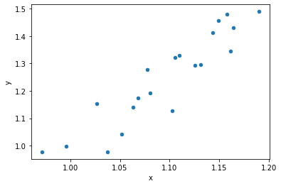

```python
# create a scatter plot to determine is data coreelated or not
sample_dataset.plot.scatter(x='x',y='y')
```

```python
data=pd.read_csv('C:/Users/ACER/OneDrive - Azerbaijan State Oil and Industry University/Desktop/Data Science with Rune/files/sample_height.csv')
```

```python
data.head()
```

|  | height |
| --- | --- |
| 0 | 129.150282 |
| 1 | 163.277930 |
| 2 | 173.965641 |
| 3 | 168.933825 |
| 4 | 171.075462 |

```python
data.columns
```

```
Index(['height'], dtype='object')
```

```python
# checking missing data
data.isna().any()
```

```
height    False
dtype: bool
```

```python
data.isnull().any()
```

```
height    False
dtype: bool
```

To create histogram fayl_adi.plot.hist()

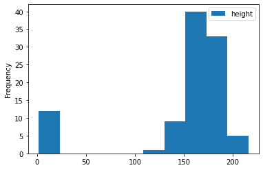

```python
# we can observe the distribution of data
data.plot.hist()
```

```python
# show us specific values which height is less than 50
data[data['height']<50]
```

|  | height |
| --- | --- |
| 17 | 1.913196 |
| 22 | 1.629159 |
| 23 | 1.753424 |
| 27 | 1.854795 |
| 50 | 1.914587 |
| 60 | 1.642295 |
| 73 | 1.804588 |
| 82 | 1.573621 |
| 91 | 1.550227 |
| 94 | 1.660700 |
| 97 | 1.675962 |
| 98 | 1.712382 |

```python
data[data['height']>125]
```

|  | height |
| --- | --- |
| 0 | 129.150282 |
| 1 | 163.277930 |
| 2 | 173.965641 |
| 3 | 168.933825 |
| 4 | 171.075462 |
| ... | ... |
| 92 | 203.475711 |
| 93 | 182.149262 |
| 95 | 173.809723 |
| 96 | 189.045440 |
| 99 | 164.930814 |

88 rows × 1 columns

```python
data_1=pd.read_csv('C:/Users/ACER/OneDrive - Azerbaijan State Oil and Industry University/Desktop/Data Science with Rune/files/sample_age.csv')
```

```python
data_1.head()
```

|  | age |
| --- | --- |
| 0 | 30.175921 |
| 1 | 32.002551 |
| 2 | 44.518393 |
| 3 | 56.247751 |
| 4 | 33.111986 |

```python
data_1.columns
```

```
Index(['age'], dtype='object')
```

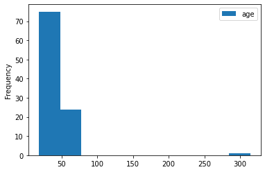

```python
data_1.plot.hist()
```

```python
data_1.isna().any()
```

```
age    False
dtype: bool
```

```python
data_1.isnull().any()
```

```
age    False
dtype: bool
```

Butun lazimli statistik deyerlere birlikde baxmaq istedikde fayl_adi.describe()

```python
#This code part gives us import and basic statistics of our dataset
# count, mean,standart deviation,minimum,maximum,quartiles
data_1.describe()
```

|  | age |
| --- | --- |
| count | 100.000000 |
| mean | 42.305997 |
| std | 29.229478 |
| min | 18.273781 |
| 25% | 31.871113 |
| 50% | 39.376896 |
| 75% | 47.779303 |
| max | 314.000000 |

```python
data_1.mean()
```

```
age    42.305997
dtype: float64
```

```python
data_1.std()
```

```
age    29.229478
dtype: float64
```

```python
data_1[data_1['age']>100]
```

|  | age |
| --- | --- |
| 31 | 314.0 |

Data Exploration

```python
# idleri ve ya index columns(hansi ki datanin ilk sutununda gelir ve columnun sayini gosterir) aradan qaldirmaq ucun datani import ederken index_col=0 yaza bilerik
data_bank=pd.read_csv('C:/Users/ACER/OneDrive - Azerbaijan State Oil and Industry University/Desktop/Data Science with Rune/files/WorldBank-ATM.CO2E.PC_DS2.csv',index_col=0)
```

```python
data_bank
```

| Year | ABW | AFE | AFG | AFW | AGO | ALB | AND | ARB | ARE | ARG | ... | VIR | VNM | VUT | WLD | WSM | XKX | YEM | ZAF | ZMB | ZWE |
| --- | --- | --- | --- | --- | --- | --- | --- | --- | --- | --- | --- | --- | --- | --- | --- | --- | --- | --- | --- | --- | --- |
| 1960 | 204.631696 | 0.906060 | 0.046057 | 0.090880 | 0.100835 | 1.258195 | NaN | 0.609268 | 0.119037 | 2.383343 | ... | NaN | 0.181947 | NaN | 3.121158 | 0.135031 | NaN | 0.011038 | 5.727223 | NaN | NaN |
| 1961 | 208.837879 | 0.922474 | 0.053589 | 0.095283 | 0.082204 | 1.374186 | NaN | 0.662618 | 0.109136 | 2.458551 | ... | NaN | 0.183099 | NaN | 3.068090 | 0.163542 | NaN | 0.013599 | 5.832621 | NaN | NaN |
| 1962 | 226.081890 | 0.930816 | 0.073721 | 0.096612 | 0.210533 | 1.439956 | NaN | 0.727117 | 0.163542 | 2.538447 | ... | NaN | 0.217694 | 0.595002 | 3.114839 | 0.158377 | NaN | 0.012729 | 5.887168 | NaN | NaN |
| 1963 | 214.785217 | 0.940570 | 0.074161 | 0.112376 | 0.202739 | 1.181681 | NaN | 0.853116 | 0.175833 | 2.330685 | ... | NaN | 0.196997 | 0.471849 | 3.221195 | 0.184037 | NaN | 0.014518 | 5.961337 | NaN | NaN |
| 1964 | 207.626699 | 0.996033 | 0.086174 | 0.133258 | 0.213562 | 1.111742 | NaN | 0.972381 | 0.132815 | 2.553442 | ... | NaN | 0.209870 | 0.864427 | 3.324046 | 0.208106 | NaN | 0.017550 | 6.332343 | 0.946606 | 1.034904 |
| 1965 | 185.213644 | 1.047280 | 0.101285 | 0.184803 | 0.205891 | 1.166099 | NaN | 1.138674 | 0.146822 | 2.656466 | ... | NaN | 0.217934 | 0.641878 | 3.432395 | 0.230892 | NaN | 0.017926 | 6.616545 | 1.096875 | 1.166242 |
| 1966 | 172.158729 | 1.033908 | 0.107399 | 0.193676 | 0.268937 | 1.333055 | NaN | 1.251997 | 0.160452 | 2.806896 | ... | NaN | 0.225434 | 1.008051 | 3.534191 | 0.196438 | NaN | 0.017023 | 6.453858 | 0.951122 | 1.307904 |
| 1967 | 210.819017 | 1.052204 | 0.123409 | 0.189305 | 0.172096 | 1.363746 | NaN | 1.316087 | 5.400016 | 2.871099 | ... | NaN | 0.195461 | 1.074339 | 3.585995 | 0.191301 | NaN | 0.017380 | 6.560824 | 1.261960 | 1.108579 |
| 1968 | 194.917536 | 1.079727 | 0.115142 | 0.143989 | 0.289702 | 1.519551 | NaN | 1.457734 | 6.807102 | 2.981777 | ... | NaN | 0.203764 | 0.772928 | 3.704543 | 0.213378 | NaN | 0.021384 | 6.593620 | 1.166853 | 1.291861 |
| 1969 | 253.544574 | 1.104632 | 0.086510 | 0.202129 | 0.480199 | 1.558968 | NaN | 1.767051 | 101.053155 | 3.288161 | ... | NaN | 0.201174 | 0.530680 | 3.875169 | 0.208805 | NaN | 0.022253 | 6.665435 | 1.056845 | 1.320782 |
| 1970 | 281.962316 | 1.123261 | 0.149651 | 0.302643 | 0.608224 | 1.753240 | NaN | 1.797938 | 65.017509 | 3.464527 | ... | NaN | 0.649680 | 0.472474 | 4.147851 | 0.204938 | NaN | 0.027236 | 6.785927 | 0.902039 | 1.543252 |
| 1971 | 243.862101 | 1.219593 | 0.165208 | 0.392109 | 0.564505 | 1.989498 | NaN | 1.997325 | 76.349852 | 3.666159 | ... | NaN | 0.551402 | 0.666636 | 4.231788 | 0.252189 | NaN | 0.034394 | 7.437298 | 0.877861 | 1.596159 |
| 1972 | 234.851226 | 1.209263 | 0.129996 | 0.459993 | 0.721198 | 2.515914 | NaN | 2.119313 | 70.865256 | 3.657009 | ... | NaN | 0.506232 | 0.686538 | 4.347295 | 0.248956 | NaN | 0.039593 | 7.376049 | 0.910557 | 1.449631 |
| 1973 | 258.849924 | 1.204523 | 0.135367 | 0.538522 | 0.751203 | 2.303897 | NaN | 2.400508 | 77.619135 | 3.754155 | ... | NaN | 0.538520 | 0.586726 | 4.493253 | 0.246342 | NaN | 0.050203 | 7.256839 | 0.993838 | 1.579042 |
| 1974 | 233.492788 | 1.186045 | 0.154503 | 0.635966 | 0.720750 | 1.849007 | NaN | 2.280801 | 67.016177 | 3.753366 | ... | NaN | 0.400421 | 0.644178 | 4.403582 | 0.219740 | NaN | 0.055862 | 7.198226 | 0.879396 | 1.488476 |
| 1975 | 168.740161 | 1.181139 | 0.167612 | 0.514018 | 0.628569 | 1.910634 | NaN | 2.193993 | 56.667471 | 3.670151 | ... | NaN | 0.447478 | 0.550805 | 4.342629 | 0.387650 | NaN | 0.089179 | 7.350684 | 0.825640 | 1.321987 |
| 1976 | 360.853233 | 1.190203 | 0.153558 | 0.550024 | 0.451346 | 2.013585 | NaN | 2.581496 | 62.156537 | 3.799262 | ... | NaN | 0.279673 | 0.427215 | 4.493091 | 0.312880 | NaN | 0.104727 | 7.474399 | 0.787503 | 1.671492 |
| 1977 | 189.163403 | 1.182218 | 0.181522 | 0.516337 | 0.469216 | 2.275876 | NaN | 2.644692 | 52.744975 | 3.780416 | ... | NaN | 0.300361 | 0.483381 | 4.558983 | 0.526531 | NaN | 0.120553 | 7.550740 | 0.708081 | 1.385335 |
| 1978 | 161.806329 | 1.169158 | 0.161894 | 0.508536 | 0.694731 | 2.530625 | NaN | 2.758893 | 53.637958 | 3.792882 | ... | NaN | 0.296767 | 0.536322 | 4.653016 | 0.690602 | NaN | 0.128100 | 7.446834 | 0.635726 | 1.341457 |
| 1979 | 170.105949 | 1.216901 | 0.167066 | 0.648273 | 0.683059 | 2.898209 | NaN | 2.860875 | 39.289061 | 4.029809 | ... | NaN | 0.306646 | 0.553913 | 4.696086 | 0.616143 | NaN | 0.136263 | 7.866689 | 0.637300 | 1.319809 |
| 1980 | 174.694594 | 1.235911 | 0.131783 | 0.634541 | 0.640966 | 1.935058 | NaN | 3.091803 | 36.198563 | 3.897888 | ... | NaN | 0.309874 | 0.539274 | 4.601082 | 0.636624 | NaN | 0.150523 | 7.999998 | 0.603457 | 1.300764 |
| 1981 | 165.121266 | 1.319764 | 0.150615 | 0.604714 | 0.611133 | 2.693024 | NaN | 2.924498 | 33.610204 | 3.600810 | ... | NaN | 0.319261 | 0.433064 | 4.406638 | 0.656454 | NaN | 0.165266 | 8.773994 | 0.555922 | 1.229248 |
| 1982 | 182.270961 | 1.367397 | 0.163104 | 0.599649 | 0.519353 | 2.624857 | NaN | 2.710726 | 31.654515 | 3.591793 | ... | NaN | 0.323557 | 0.422890 | 4.314960 | 0.722378 | NaN | 0.229252 | 9.311609 | 0.561825 | 1.107255 |
| 1983 | 92.363156 | 1.386367 | 0.201224 | 0.539567 | 0.551348 | 2.683240 | NaN | 2.806025 | 28.769868 | 3.595564 | ... | NaN | 0.332215 | 0.442828 | 4.286135 | 0.717907 | NaN | 0.280730 | 9.428690 | 0.504630 | 1.267386 |
| 1984 | 228.392242 | 1.431964 | 0.231961 | 0.581373 | 0.520983 | 2.694291 | NaN | 2.970001 | 35.854683 | 3.582148 | ... | NaN | 0.294900 | 0.432913 | 4.339077 | 0.713859 | NaN | 0.320009 | 9.922518 | 0.420787 | 1.158912 |
| 1985 | 266.483562 | 1.423145 | 0.293957 | 0.583495 | 0.471903 | 2.658015 | NaN | 3.044787 | 36.544784 | 3.329225 | ... | NaN | 0.347571 | 0.930933 | 4.428312 | 0.710503 | NaN | 0.329840 | 9.921214 | 0.397784 | 1.156175 |
| 1986 | 2.868274 | 1.420777 | 0.267772 | 0.543988 | 0.451619 | 2.665356 | NaN | 3.271082 | 32.657000 | 3.394658 | ... | NaN | 0.370680 | 0.441183 | 4.412252 | 0.708039 | NaN | 0.317230 | 9.877463 | 0.404311 | 1.426918 |
| 1987 | 7.234613 | 1.390142 | 0.269230 | 0.474906 | 0.544085 | 2.414061 | NaN | 3.183741 | 31.100224 | 3.685884 | ... | NaN | 0.407675 | 0.350329 | 4.461923 | 0.706235 | NaN | 0.325062 | 9.593208 | 0.366559 | 1.599636 |
| 1988 | 10.027328 | 1.407205 | 0.246823 | 0.534962 | 0.463508 | 2.331599 | NaN | 3.277904 | 29.726926 | 3.835716 | ... | NaN | 0.355998 | 0.473776 | 4.565403 | 0.704454 | NaN | 0.317462 | 9.773400 | 0.413597 | 1.634845 |
| 1989 | 10.634558 | 1.357144 | 0.233882 | 0.414090 | 0.437295 | 2.783243 | NaN | 3.238796 | 31.574845 | 3.642232 | ... | NaN | 0.263108 | 0.436545 | 4.566474 | 0.747281 | NaN | 0.312652 | 9.493668 | 0.332929 | 1.594088 |
| 1990 | NaN | 1.017505 | 0.238473 | 0.440470 | 0.534250 | 1.840841 | 7.521832 | 2.870779 | 30.299102 | 3.060826 | ... | NaN | 0.270780 | 0.477571 | 3.902964 | 0.675688 | NaN | 0.567037 | 6.729799 | 0.340930 | 1.584485 |
| 1991 | NaN | 0.971324 | 0.206030 | 0.474868 | 0.533109 | 1.258116 | 7.235379 | 2.912911 | 31.747523 | 3.183893 | ... | NaN | 0.263692 | 0.464444 | 3.874591 | 0.670732 | NaN | 0.690937 | 6.424622 | 0.349232 | 1.713321 |
| 1992 | NaN | 0.931920 | 0.098719 | 0.516677 | 0.503264 | 0.689859 | 6.963079 | 2.959286 | 29.051699 | 3.201675 | ... | NaN | 0.272419 | 0.386658 | 3.804011 | 0.725119 | NaN | 0.704793 | 6.175430 | 0.337224 | 1.694416 |
| 1993 | NaN | 0.925465 | 0.085986 | 0.518952 | 0.527723 | 0.641406 | 6.724178 | 3.082222 | 28.599236 | 3.268462 | ... | NaN | 0.335407 | 0.375603 | 3.769328 | 0.718060 | NaN | 0.595566 | 6.217680 | 0.291111 | 1.539741 |
| 1994 | NaN | 0.918612 | 0.076131 | 0.492858 | 0.495418 | 0.667179 | 6.541579 | 3.166690 | 29.764071 | 3.308174 | ... | NaN | 0.363198 | 0.365568 | 3.732385 | 0.711368 | NaN | 0.593106 | 6.212642 | 0.241270 | 1.417186 |
| 1995 | NaN | 0.946475 | 0.069020 | 0.487495 | 0.773026 | 0.611710 | 6.733479 | 3.161191 | 30.077442 | 3.267757 | ... | NaN | 0.404750 | 0.416268 | 3.781982 | 0.705675 | NaN | 0.661825 | 6.375894 | 0.234153 | 1.356619 |
| 1996 | NaN | 0.951132 | 0.062588 | 0.507633 | 0.792321 | 0.621837 | 6.991595 | 3.196048 | 29.856789 | 3.590724 | ... | NaN | 0.449199 | 0.524106 | 3.806694 | 0.759501 | NaN | 0.651614 | 6.486114 | 0.188442 | 1.287559 |
| 1997 | NaN | 0.971563 | 0.056827 | 0.488416 | 0.788753 | 0.470098 | 7.307441 | 3.213285 | 30.490076 | 3.570644 | ... | NaN | 0.520398 | 0.514530 | 3.813515 | 0.755528 | NaN | 0.679157 | 6.721030 | 0.237559 | 1.186793 |
| 1998 | NaN | 0.969680 | 0.053197 | 0.461622 | 0.740254 | 0.575350 | 7.639539 | 3.163145 | 29.805767 | 3.692658 | ... | NaN | 0.574404 | 0.449471 | 3.780611 | 0.810002 | NaN | 0.713057 | 6.787882 | 0.219937 | 1.197745 |
| 1999 | NaN | 0.908374 | 0.040653 | 0.453549 | 0.797259 | 0.955359 | 7.923192 | 3.131299 | 28.994996 | 3.679743 | ... | NaN | 0.571513 | 0.496527 | 3.747766 | 0.806424 | NaN | 0.778316 | 6.280539 | 0.173560 | 1.338101 |
| 2000 | NaN | 0.900399 | 0.037055 | 0.447244 | 0.754476 | 1.026213 | 7.952286 | 3.163305 | 26.974535 | 3.577628 | ... | NaN | 0.629580 | 0.486581 | 3.812649 | 0.859826 | NaN | 0.797860 | 6.331876 | 0.173772 | 1.153055 |
| 2001 | NaN | 0.971981 | 0.037488 | 0.474140 | 0.761843 | 1.052228 | 7.721549 | 3.282509 | 29.145656 | 3.349909 | ... | NaN | 0.692572 | 0.475664 | 3.827659 | 0.855217 | NaN | 0.841594 | 7.035134 | 0.171153 | 1.165725 |
| 2002 | NaN | 0.975749 | 0.048671 | 0.474875 | 0.777423 | 1.229101 | 7.566240 | 3.347227 | 28.205380 | 3.117425 | ... | NaN | 0.812908 | 0.412526 | 3.834751 | 0.906978 | NaN | 0.820877 | 7.181223 | 0.174996 | 1.044813 |
| 2003 | NaN | 1.009963 | 0.057008 | 0.474592 | 0.993848 | 1.352144 | 7.242416 | 3.361728 | 27.891143 | 3.370102 | ... | NaN | 0.856119 | 0.452352 | 3.958503 | 0.901505 | NaN | 0.916513 | 7.558134 | 0.185667 | 0.849592 |
| 2004 | NaN | 1.057182 | 0.045700 | 0.474318 | 1.028354 | 1.417273 | 7.344262 | 3.474240 | 27.031564 | 3.685184 | ... | NaN | 1.016821 | 0.342930 | 4.092252 | 0.951864 | NaN | 0.941654 | 8.034618 | 0.182674 | 0.812818 |
| 2005 | NaN | 1.032998 | 0.063927 | 0.509458 | 0.937037 | 1.351492 | 7.353780 | 3.704298 | 25.343150 | 3.762124 | ... | NaN | 1.097901 | 0.334477 | 4.196301 | 1.057188 | NaN | 0.963823 | 7.887120 | 0.193147 | 0.870271 |
| 2006 | NaN | 1.023646 | 0.073393 | 0.487953 | 1.009434 | 1.353362 | 6.790543 | 3.801646 | 22.916237 | 3.954454 | ... | NaN | 1.131680 | 0.326525 | 4.281006 | 1.050455 | NaN | 0.938241 | 7.827680 | 0.179077 | 0.808688 |
| 2007 | NaN | 1.045968 | 0.087083 | 0.475148 | 1.123635 | 1.420867 | 6.531047 | 3.883140 | 21.347591 | 4.123293 | ... | NaN | 1.233675 | 0.501221 | 4.391867 | 1.043698 | NaN | 0.969340 | 8.080250 | 0.158363 | 0.796350 |
| 2008 | NaN | 1.086449 | 0.158356 | 0.475025 | 1.155993 | 1.414848 | 6.439304 | 4.093538 | 22.032627 | 4.195343 | ... | NaN | 1.363814 | 0.445038 | 4.376917 | 1.036722 | NaN | 1.005383 | 8.568994 | 0.169669 | 0.613916 |
| 2009 | NaN | 1.021954 | 0.211306 | 0.426770 | 1.205902 | 1.475652 | 6.156688 | 4.193272 | 19.852557 | 3.889060 | ... | NaN | 1.512419 | 0.564618 | 4.277131 | 1.029515 | NaN | 1.139166 | 8.004039 | 0.186907 | 0.618665 |
| 2010 | NaN | 1.048876 | 0.297065 | 0.472819 | 1.221515 | 1.572251 | 6.157198 | 4.322002 | 19.043279 | 4.122245 | ... | NaN | 1.698806 | 0.550344 | 4.483148 | 1.021813 | NaN | 1.036068 | 8.300179 | 0.194032 | 0.772579 |
| 2011 | NaN | 1.005338 | 0.407074 | 0.497023 | 1.216317 | 1.734823 | 5.850886 | 4.308741 | 18.589933 | 4.296015 | ... | NaN | 1.676805 | 0.535733 | 4.570123 | 1.066843 | NaN | 0.869051 | 7.867124 | 0.218210 | 0.891090 |
| 2012 | NaN | 1.021646 | 0.335351 | 0.490867 | 1.204799 | 1.579092 | 5.944654 | 4.512189 | 19.223116 | 4.277882 | ... | NaN | 1.639943 | 0.480952 | 4.578768 | 1.057703 | NaN | 0.804146 | 8.076633 | 0.277909 | 0.923360 |
| 2013 | NaN | 1.031833 | 0.263716 | 0.504655 | 1.261542 | 1.654524 | 5.942801 | 4.495194 | 20.015421 | 4.359886 | ... | NaN | 1.692844 | 0.428621 | 4.610229 | 1.048702 | NaN | 1.047834 | 8.137333 | 0.284058 | 0.925816 |
| 2014 | NaN | 1.041145 | 0.234037 | 0.507671 | 1.285365 | 1.806789 | 5.807128 | 4.600191 | 19.951852 | 4.216361 | ... | NaN | 1.837890 | 0.606318 | 4.560774 | 1.092498 | NaN | 1.034330 | 8.213158 | 0.311693 | 0.894256 |
| 2015 | NaN | 0.987393 | 0.232176 | 0.480743 | 1.260921 | 1.759987 | 6.026182 | 4.617964 | 20.948092 | 4.314434 | ... | NaN | 2.257300 | 0.516361 | 4.488770 | 1.240246 | NaN | 0.536269 | 7.671202 | 0.319282 | 0.897598 |
| 2016 | NaN | 0.971016 | 0.208857 | 0.472959 | 1.227703 | 1.714126 | 6.080600 | 4.570308 | 21.307610 | 4.227539 | ... | NaN | 2.390741 | 0.646724 | 4.436759 | 1.542099 | NaN | 0.400468 | 7.564451 | 0.341615 | 0.783303 |
| 2017 | NaN | 0.959978 | 0.203328 | 0.476438 | 1.034317 | 1.948872 | 6.104134 | 4.528351 | 21.950614 | 4.089472 | ... | NaN | 2.348081 | 0.595449 | 4.441309 | 1.535642 | NaN | 0.361418 | 7.632729 | 0.414748 | 0.718570 |
| 2018 | NaN | 0.933541 | 0.200151 | 0.515544 | 0.887380 | 1.939732 | 5.973405 | 4.438716 | 20.797498 | 3.987234 | ... | NaN | 2.698806 | 0.615017 | 4.483524 | 1.631588 | NaN | 0.326682 | 7.496645 | 0.446065 | 0.849793 |

59 rows × 266 columns

```python
data_bank.head(10)
```

| Year | ABW | AFE | AFG | AFW | AGO | ALB | AND | ARB | ARE | ARG | ... | VIR | VNM | VUT | WLD | WSM | XKX | YEM | ZAF | ZMB | ZWE |
| --- | --- | --- | --- | --- | --- | --- | --- | --- | --- | --- | --- | --- | --- | --- | --- | --- | --- | --- | --- | --- | --- |
| 1960 | 204.631696 | 0.906060 | 0.046057 | 0.090880 | 0.100835 | 1.258195 | NaN | 0.609268 | 0.119037 | 2.383343 | ... | NaN | 0.181947 | NaN | 3.121158 | 0.135031 | NaN | 0.011038 | 5.727223 | NaN | NaN |
| 1961 | 208.837879 | 0.922474 | 0.053589 | 0.095283 | 0.082204 | 1.374186 | NaN | 0.662618 | 0.109136 | 2.458551 | ... | NaN | 0.183099 | NaN | 3.068090 | 0.163542 | NaN | 0.013599 | 5.832621 | NaN | NaN |
| 1962 | 226.081890 | 0.930816 | 0.073721 | 0.096612 | 0.210533 | 1.439956 | NaN | 0.727117 | 0.163542 | 2.538447 | ... | NaN | 0.217694 | 0.595002 | 3.114839 | 0.158377 | NaN | 0.012729 | 5.887168 | NaN | NaN |
| 1963 | 214.785217 | 0.940570 | 0.074161 | 0.112376 | 0.202739 | 1.181681 | NaN | 0.853116 | 0.175833 | 2.330685 | ... | NaN | 0.196997 | 0.471849 | 3.221195 | 0.184037 | NaN | 0.014518 | 5.961337 | NaN | NaN |
| 1964 | 207.626699 | 0.996033 | 0.086174 | 0.133258 | 0.213562 | 1.111742 | NaN | 0.972381 | 0.132815 | 2.553442 | ... | NaN | 0.209870 | 0.864427 | 3.324046 | 0.208106 | NaN | 0.017550 | 6.332343 | 0.946606 | 1.034904 |
| 1965 | 185.213644 | 1.047280 | 0.101285 | 0.184803 | 0.205891 | 1.166099 | NaN | 1.138674 | 0.146822 | 2.656466 | ... | NaN | 0.217934 | 0.641878 | 3.432395 | 0.230892 | NaN | 0.017926 | 6.616545 | 1.096875 | 1.166242 |
| 1966 | 172.158729 | 1.033908 | 0.107399 | 0.193676 | 0.268937 | 1.333055 | NaN | 1.251997 | 0.160452 | 2.806896 | ... | NaN | 0.225434 | 1.008051 | 3.534191 | 0.196438 | NaN | 0.017023 | 6.453858 | 0.951122 | 1.307904 |
| 1967 | 210.819017 | 1.052204 | 0.123409 | 0.189305 | 0.172096 | 1.363746 | NaN | 1.316087 | 5.400016 | 2.871099 | ... | NaN | 0.195461 | 1.074339 | 3.585995 | 0.191301 | NaN | 0.017380 | 6.560824 | 1.261960 | 1.108579 |
| 1968 | 194.917536 | 1.079727 | 0.115142 | 0.143989 | 0.289702 | 1.519551 | NaN | 1.457734 | 6.807102 | 2.981777 | ... | NaN | 0.203764 | 0.772928 | 3.704543 | 0.213378 | NaN | 0.021384 | 6.593620 | 1.166853 | 1.291861 |
| 1969 | 253.544574 | 1.104632 | 0.086510 | 0.202129 | 0.480199 | 1.558968 | NaN | 1.767051 | 101.053155 | 3.288161 | ... | NaN | 0.201174 | 0.530680 | 3.875169 | 0.208805 | NaN | 0.022253 | 6.665435 | 1.056845 | 1.320782 |

10 rows × 266 columns

```python
data_bank.columns
```

```
Index(['ABW', 'AFE', 'AFG', 'AFW', 'AGO', 'ALB', 'AND', 'ARB', 'ARE', 'ARG',
       ...
       'VIR', 'VNM', 'VUT', 'WLD', 'WSM', 'XKX', 'YEM', 'ZAF', 'ZMB', 'ZWE'],
      dtype='object', length=266)
```

```python
data_bank.isnull().any()
```

```
ABW     True
AFE    False
AFG    False
AFW    False
AGO    False
       ...
XKX     True
YEM    False
ZAF    False
ZMB     True
ZWE     True
Length: 266, dtype: bool
```

```python
data_bank.isna().any()
```

```
ABW     True
AFE    False
AFG    False
AFW    False
AGO    False
       ...
XKX     True
YEM    False
ZAF    False
ZMB     True
ZWE     True
Length: 266, dtype: bool
```

Correlationa baxmaq ucun fayl_adi.corr()

```python
data_bank.corr()
```

|  | ABW | AFE | AFG | AFW | AGO | ALB | AND | ARB | ARE | ARG | ... | VIR | VNM | VUT | WLD | WSM | XKX | YEM | ZAF | ZMB | ZWE |
| --- | --- | --- | --- | --- | --- | --- | --- | --- | --- | --- | --- | --- | --- | --- | --- | --- | --- | --- | --- | --- | --- |
| ABW | 1.000000 | -0.453351 | -0.502958 | -0.180877 | -0.020925 | -0.367901 | NaN | -0.437307 | 0.264335 | -0.168328 | ... | NaN | 0.059608 | 0.308816 | -0.240711 | -0.598962 | NaN | -0.619561 | -0.545527 | 0.572760 | -0.139282 |
| AFE | -0.453351 | 1.000000 | 0.466669 | 0.402718 | -0.184936 | 0.845522 | -0.330496 | -0.020922 | 0.408673 | 0.205929 | ... | NaN | -0.302655 | 0.006856 | 0.561878 | -0.171457 | NaN | -0.357308 | 0.818084 | 0.287794 | 0.333933 |
| AFG | -0.502958 | 0.466669 | 1.000000 | 0.352672 | 0.322833 | 0.591890 | -0.754110 | 0.455415 | 0.064100 | 0.513794 | ... | NaN | 0.383244 | 0.079044 | 0.669557 | 0.324964 | NaN | 0.067972 | 0.636601 | -0.047252 | -0.062881 |
| AFW | -0.180877 | 0.402718 | 0.352672 | 1.000000 | 0.535558 | 0.351148 | -0.355787 | 0.703690 | 0.421373 | 0.736751 | ... | NaN | 0.243532 | -0.454301 | 0.780845 | 0.536641 | NaN | 0.382559 | 0.575304 | -0.508005 | 0.033947 |
| AGO | -0.020925 | -0.184936 | 0.322833 | 0.535558 | 1.000000 | -0.045108 | -0.657879 | 0.885871 | 0.073956 | 0.844181 | ... | NaN | 0.825850 | -0.298578 | 0.598267 | 0.799578 | NaN | 0.757588 | 0.287952 | -0.627351 | -0.696369 |
| ... | ... | ... | ... | ... | ... | ... | ... | ... | ... | ... | ... | ... | ... | ... | ... | ... | ... | ... | ... | ... | ... |
| XKX | NaN | NaN | NaN | NaN | NaN | NaN | NaN | NaN | NaN | NaN | ... | NaN | NaN | NaN | NaN | NaN | NaN | NaN | NaN | NaN | NaN |
| YEM | -0.619561 | -0.357308 | 0.067972 | 0.382559 | 0.757588 | -0.394054 | 0.023232 | 0.759693 | -0.221065 | 0.484233 | ... | NaN | 0.521268 | -0.455832 | 0.202546 | 0.712634 | NaN | 1.000000 | 0.142136 | -0.869488 | -0.549881 |
| ZAF | -0.545527 | 0.818084 | 0.636601 | 0.575304 | 0.287952 | 0.738641 | -0.581636 | 0.480179 | 0.154438 | 0.539665 | ... | NaN | 0.191596 | -0.176530 | 0.744338 | 0.371909 | NaN | 0.142136 | 1.000000 | -0.205701 | -0.157057 |
| ZMB | 0.572760 | 0.287794 | -0.047252 | -0.508005 | -0.627351 | 0.283306 | -0.433457 | -0.810150 | 0.324146 | -0.433598 | ... | NaN | -0.418981 | 0.613547 | -0.153164 | -0.776531 | NaN | -0.869488 | -0.205701 | 1.000000 | 0.382014 |
| ZWE | -0.139282 | 0.333933 | -0.062881 | 0.033947 | -0.696369 | 0.150780 | 0.489735 | -0.567265 | 0.491675 | -0.421842 | ... | NaN | -0.736541 | -0.058129 | -0.132377 | -0.659468 | NaN | -0.549881 | -0.157057 | 0.382014 | 1.000000 |

266 rows × 266 columns

```python
data_bank.corr()["ZWE"]
```

```
ABW   -0.139282
AFE    0.333933
AFG   -0.062881
AFW    0.033947
AGO   -0.696369
         ...
XKX         NaN
YEM   -0.549881
ZAF   -0.157057
ZMB    0.382014
ZWE    1.000000
Name: ZWE, Length: 266, dtype: float64
```

```python
data_bank.dtypes
```

```
ABW    float64
AFE    float64
AFG    float64
AFW    float64
AGO    float64
        ...
XKX    float64
YEM    float64
ZAF    float64
ZMB    float64
ZWE    float64
Length: 266, dtype: object
```

```python
data_bank.describe()
```

|  | ABW | AFE | AFG | AFW | AGO | ALB | AND | ARB | ARE | ARG | ... | VIR | VNM | VUT | WLD | WSM | XKX | YEM | ZAF | ZMB | ZWE |
| --- | --- | --- | --- | --- | --- | --- | --- | --- | --- | --- | --- | --- | --- | --- | --- | --- | --- | --- | --- | --- | --- |
| count | 30.000000 | 59.000000 | 59.000000 | 59.000000 | 59.000000 | 59.000000 | 29.000000 | 59.000000 | 59.000000 | 59.000000 | ... | 0.0 | 59.000000 | 57.000000 | 59.000000 | 59.000000 | 0.0 | 59.000000 | 59.000000 | 55.000000 | 55.000000 |
| mean | 184.079829 | 1.089405 | 0.149382 | 0.440692 | 0.687540 | 1.660433 | 6.778152 | 2.923164 | 30.416576 | 3.544621 | ... | NaN | 0.716099 | 0.530864 | 4.109284 | 0.693014 | NaN | 0.442130 | 7.497467 | 0.479936 | 1.201970 |
| std | 84.724762 | 0.157525 | 0.085583 | 0.147548 | 0.329161 | 0.643504 | 0.688945 | 1.089531 | 20.916706 | 0.512579 | ... | NaN | 0.652798 | 0.154410 | 0.440680 | 0.371951 | NaN | 0.369435 | 1.136301 | 0.313848 | 0.302564 |
| min | 2.868274 | 0.900399 | 0.037055 | 0.090880 | 0.082204 | 0.470098 | 5.807128 | 0.609268 | 0.109136 | 2.330685 | ... | NaN | 0.181947 | 0.326525 | 3.068090 | 0.135031 | NaN | 0.011038 | 5.727223 | 0.158363 | 0.613916 |
| 25% | 169.081608 | 0.971170 | 0.073941 | 0.443857 | 0.476051 | 1.258155 | 6.104134 | 2.340655 | 20.406460 | 3.278312 | ... | NaN | 0.287286 | 0.436545 | 3.805353 | 0.282534 | NaN | 0.072521 | 6.577222 | 0.219073 | 0.910479 |
| 50% | 199.774616 | 1.033908 | 0.149651 | 0.476438 | 0.640966 | 1.572251 | 6.733479 | 3.091803 | 28.994996 | 3.642232 | ... | NaN | 0.404750 | 0.486581 | 4.281006 | 0.711368 | NaN | 0.326682 | 7.446834 | 0.349232 | 1.229248 |
| 75% | 232.217652 | 1.188124 | 0.207444 | 0.515941 | 0.912209 | 2.001541 | 7.344262 | 3.417984 | 33.133602 | 3.862388 | ... | NaN | 0.936470 | 0.586726 | 4.472535 | 0.929421 | NaN | 0.788088 | 8.055625 | 0.672690 | 1.422052 |
| max | 360.853233 | 1.431964 | 0.407074 | 0.648273 | 1.285365 | 2.898209 | 7.952286 | 4.617964 | 101.053155 | 4.359886 | ... | NaN | 2.698806 | 1.074339 | 4.696086 | 1.631588 | NaN | 1.139166 | 9.922518 | 1.261960 | 1.713321 |

8 rows × 266 columns

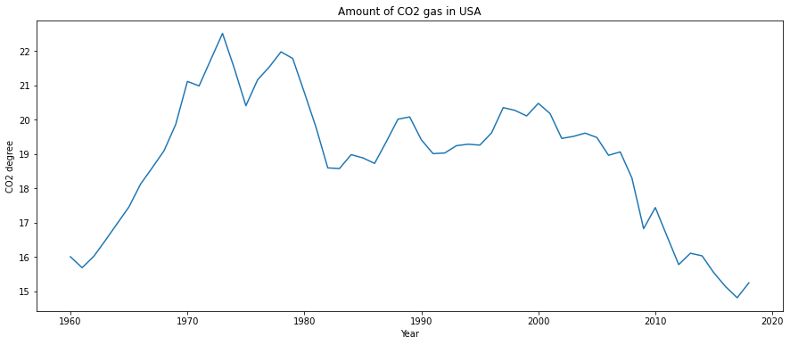

```python
data_bank['USA'].plot(title='Amount of CO2 gas in USA',xlabel='Year',ylabel='CO2 degree',figsize=(15,6))
```

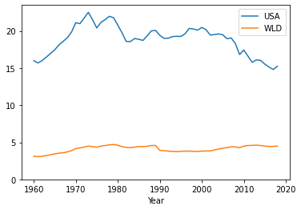

```python
data_bank[['USA','WLD']].plot(ylim=0) # ylim=0 yazanda vizualizationda tesvirim 0-dan baslasin isteyirem demekdir
```

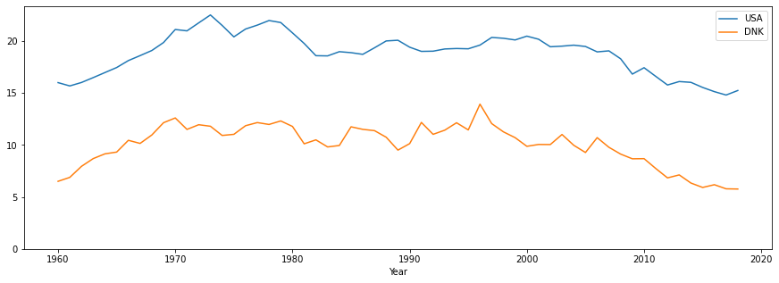

```python
data_bank[['USA','DNK']].plot(ylim=0,figsize=(15,5)) # figsize stretchs plot and help us to compare more easily and effectively
```

Plot qurmaq ucun fayl_adi[['column1','column2']].plot(ylim=0)

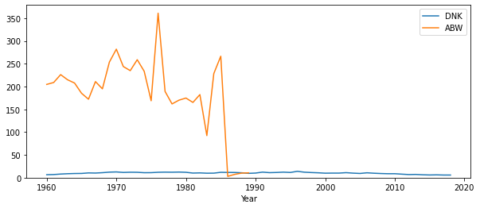

```python
data_bank[['DNK','ABW']].plot(ylim=0,figsize=(10,4))
```

Barplot qurmaq ucun fayl_adi['column'].plot.bar(icine parametrler yazmaq olar) Iki columnun deyerlerini muqayise etmek ucun bar plot quranda fayl_adi[['column1','column2']].plot.bar()

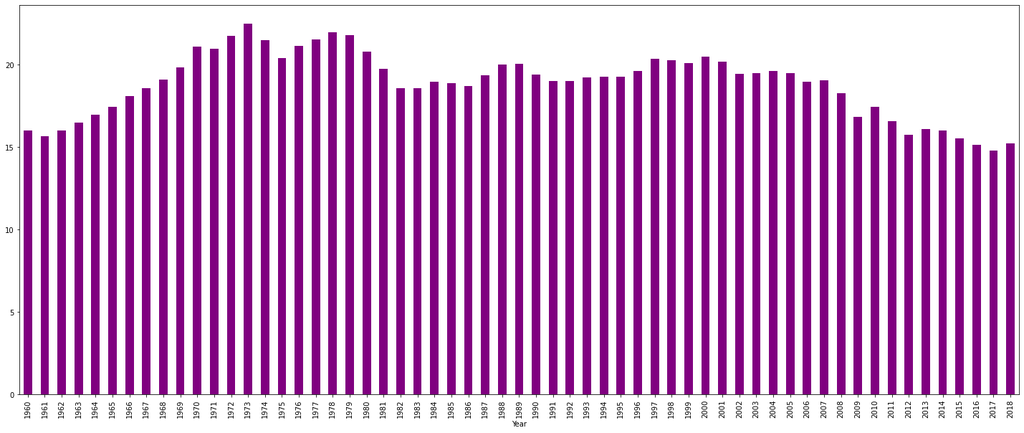

```python
# barplot
data_bank['USA'].plot.bar(figsize=(25,10),color='purple')
```

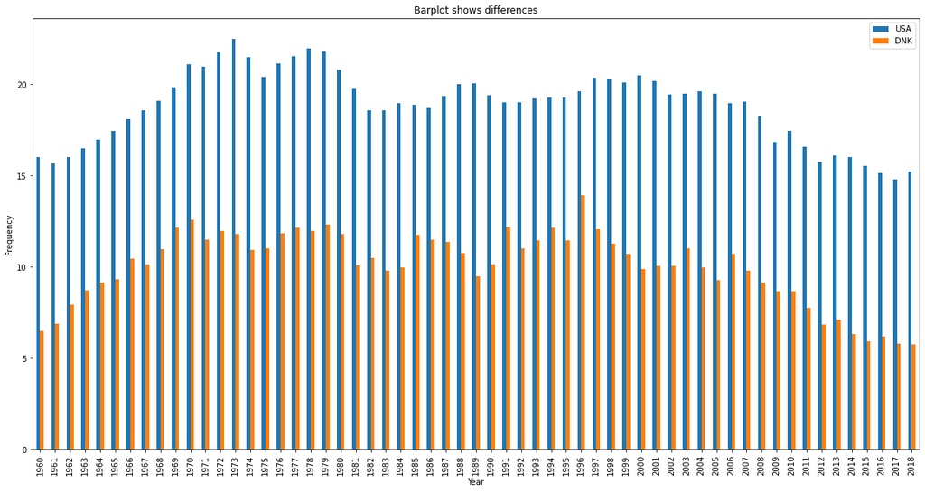

```python
#fayli import ederken qoydugum ad['column_adi'].plot.bar()
#plot ucun elave parameterler yazmaq olar mes title,xlabel,ylabel,figsize=()
data_bank[['USA','DNK']].plot.bar(title='Barplot shows differences',ylabel='Frequency',figsize=(20,10))
```

X oxunda verilmis columnun mueyyen deyer araligininn tesviri lazim olanda fay_adi[['column1','column2']].loc[baslangic deyer:son deyer].plot.bar()

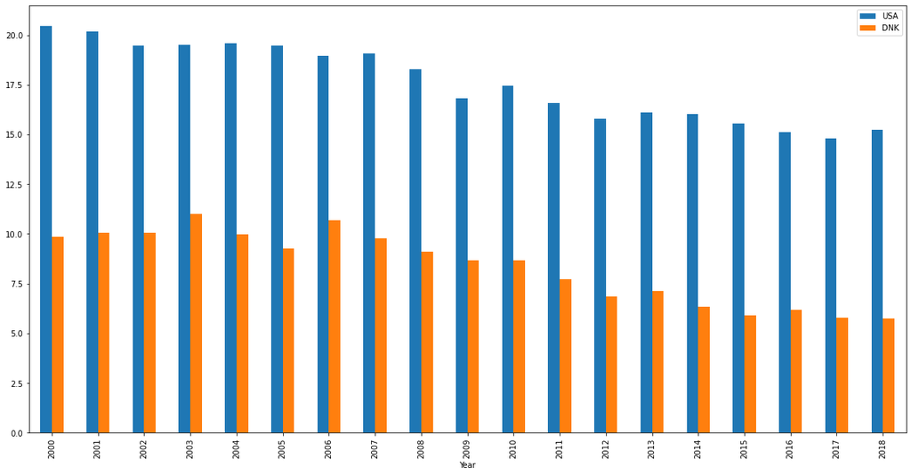

```python
# create barplot with location
data_bank[['USA','DNK']].loc[2000:].plot.bar(figsize=(20,10)) # meselen burada 2000-ci ilden sonra sona qeder olan datalarin barplotunu verir
```

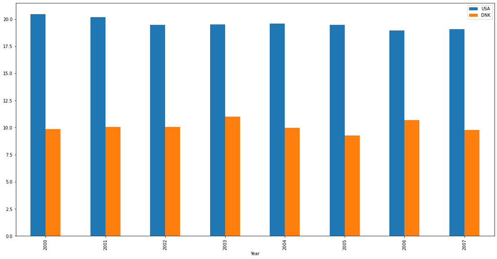

```python
data_bank[['USA','DNK']].loc[2000:2007].plot.bar(figsize=(20,10))
```

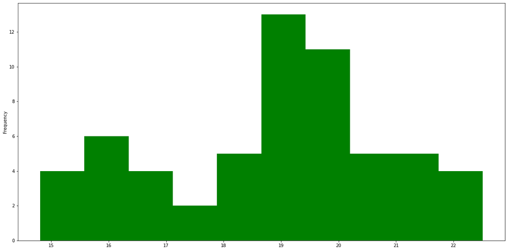

```python
data_bank['USA'].plot.hist(figsize=(20,10),color='green') # bins=10
```

To create data frame data - keyword kimidir index - keyword tiplidir pd- it represents pandas data_frame=pd.Series(data = [vermek istediyin deyerler ve ya melumatlar], index = [vermek istediyin column adlari]

```python
#We create a data frame with using Pandas
data_frame=pd.Series(data=[10,13,28,57,80],index=['Country1','Country2','Country3','Country4','Country5'])
data_frame
```

```
Country1    10
Country2    13
Country3    28
Country4    57
Country5    80
dtype: int64
```

```python
data_frame_2=pd.Series(data=['Physics','Maths','Statistics','Programming','Data science'],index=['labelname_1','labelname2','labelname3','lablename_4','labelname5'])
data_frame_2
```

```
labelname_1         Physics
labelname2            Maths
labelname3       Statistics
lablename_4     Programming
labelname5     Data science
dtype: object
```

To create a pie-chart name_of_data_frame.plot.pie(we can write all parametrs inside of here) We must pay attention that data part must be integer otherwise we will face error because both of them cannot be strings,'names'

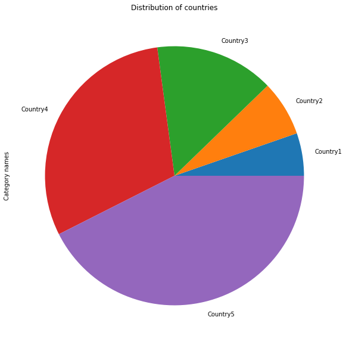

```python
# Create a pie chart
data_frame.plot.pie(title='Distribution of countries',ylabel='Category names',figsize=(15,10))
```

```python
(data_bank['DNK']<10).value_counts() # Danimarka columnunda 10-dan kicik deyerlerin sayini gosterir
```

```
False    35
True     24
Name: DNK, dtype: int64
```

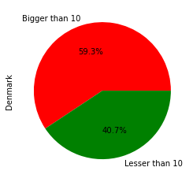

```python
(data_bank['DNK']<10).value_counts().plot.pie(ylabel='Denmark',figsize=(10,4),colors=['r','g'],labels=['Bigger than 10','Lesser than 10'],autopct='%1.1f%%')
```

```python
data_new=pd.read_csv('C:/Users/ACER/OneDrive - Azerbaijan State Oil and Industry University/Desktop/Data Science with Rune/files/co2_gdp_per_capita.csv',index_col=0)
```

```python
data_new
```

|  | CO2 per capita | GDP per capita |
| --- | --- | --- |
| AFE | 0.933541 | 1507.861055 |
| AFG | 0.200151 | 568.827927 |
| AFW | 0.515544 | 1834.366604 |
| AGO | 0.887380 | 3595.106667 |
| ALB | 1.939732 | 4433.741739 |
| ... | ... | ... |
| WSM | 1.631588 | 4297.910383 |
| YEM | 0.326682 | 1290.925239 |
| ZAF | 7.496645 | 5639.901997 |
| ZMB | 0.446065 | 1368.600235 |
| ZWE | 0.849793 | 1509.523735 |

233 rows × 2 columns

```python
data_new.head()
```

|  | CO2 per capita | GDP per capita |
| --- | --- | --- |
| AFE | 0.933541 | 1507.861055 |
| AFG | 0.200151 | 568.827927 |
| AFW | 0.515544 | 1834.366604 |
| AGO | 0.887380 | 3595.106667 |
| ALB | 1.939732 | 4433.741739 |

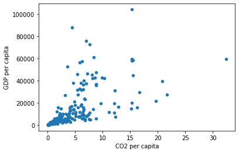

```python
data_new.plot.scatter(x='CO2 per capita',y='GDP per capita')
```

```python
data_new.corr()
```

|  | CO2 per capita | GDP per capita |
| --- | --- | --- |
| CO2 per capita | 1.000000 | 0.633178 |
| GDP per capita | 0.633178 | 1.000000 |

```python
data_world=pd.read_csv('C:/Users/ACER/OneDrive - Azerbaijan State Oil and Industry University/Desktop/Data Science with Rune/files/WorldBank-ATM.CO2E.PC_DS2.csv',index_col=0)
```

```python
data_world.head()
```

| Year | ABW | AFE | AFG | AFW | AGO | ALB | AND | ARB | ARE | ARG | ... | VIR | VNM | VUT | WLD | WSM | XKX | YEM | ZAF | ZMB | ZWE |
| --- | --- | --- | --- | --- | --- | --- | --- | --- | --- | --- | --- | --- | --- | --- | --- | --- | --- | --- | --- | --- | --- |
| 1960 | 204.631696 | 0.906060 | 0.046057 | 0.090880 | 0.100835 | 1.258195 | NaN | 0.609268 | 0.119037 | 2.383343 | ... | NaN | 0.181947 | NaN | 3.121158 | 0.135031 | NaN | 0.011038 | 5.727223 | NaN | NaN |
| 1961 | 208.837879 | 0.922474 | 0.053589 | 0.095283 | 0.082204 | 1.374186 | NaN | 0.662618 | 0.109136 | 2.458551 | ... | NaN | 0.183099 | NaN | 3.068090 | 0.163542 | NaN | 0.013599 | 5.832621 | NaN | NaN |
| 1962 | 226.081890 | 0.930816 | 0.073721 | 0.096612 | 0.210533 | 1.439956 | NaN | 0.727117 | 0.163542 | 2.538447 | ... | NaN | 0.217694 | 0.595002 | 3.114839 | 0.158377 | NaN | 0.012729 | 5.887168 | NaN | NaN |
| 1963 | 214.785217 | 0.940570 | 0.074161 | 0.112376 | 0.202739 | 1.181681 | NaN | 0.853116 | 0.175833 | 2.330685 | ... | NaN | 0.196997 | 0.471849 | 3.221195 | 0.184037 | NaN | 0.014518 | 5.961337 | NaN | NaN |
| 1964 | 207.626699 | 0.996033 | 0.086174 | 0.133258 | 0.213562 | 1.111742 | NaN | 0.972381 | 0.132815 | 2.553442 | ... | NaN | 0.209870 | 0.864427 | 3.324046 | 0.208106 | NaN | 0.017550 | 6.332343 | 0.946606 | 1.034904 |

5 rows × 266 columns

```python
data_world.columns
```

```
Index(['ABW', 'AFE', 'AFG', 'AFW', 'AGO', 'ALB', 'AND', 'ARB', 'ARE', 'ARG',
       ...
       'VIR', 'VNM', 'VUT', 'WLD', 'WSM', 'XKX', 'YEM', 'ZAF', 'ZMB', 'ZWE'],
      dtype='object', length=266)
```

```python
data_world.loc[2017].describe()
```

```
count    239.000000
mean       4.154185
std        4.575980
min        0.028010
25%        0.851900
50%        2.667119
75%        6.158644
max       32.179371
Name: 2017, dtype: float64
```

```python
data_world.loc[2017]['USA']
```

```
14.8058824221278
```

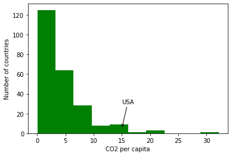

```python
ax=data_world.loc[2017].plot.hist(facecolor='green')
ax.set_xlabel('CO2 per capita')
ax.set_ylabel('Number of countries')
ax.annotate('USA', xy=(15,5),xytext=(15,30),
           arrowprops=dict(arrowstyle='->',
                          connectionstyle="arc3"))
```

```python
# To get general information about dataset
data_world.info()
```

```
<class 'pandas.core.frame.DataFrame'>
Int64Index: 59 entries, 1960 to 2018
Columns: 266 entries, ABW to ZWE
dtypes: float64(266)
memory usage: 125.1 KB
```

To deal with null or missing values which are given in dataset

```python
data_world.isnull().any()
```

```
ABW     True
AFE    False
AFG    False
AFW    False
AGO    False
       ...
XKX     True
YEM    False
ZAF    False
ZMB     True
ZWE     True
Length: 266, dtype: bool
```

```python
data_world.isnull().sum()
```

```
ABW    29
AFE     0
AFG     0
AFW     0
AGO     0
       ..
XKX    59
YEM     0
ZAF     0
ZMB     4
ZWE     4
Length: 266, dtype: int64
```

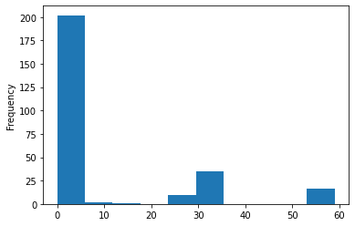

```python
data_world.isnull().sum().plot.hist()
```

To clean data removing columns which have null or missing values is one of the way. However it is not the best,appropriate way. Sometimes it works

```python
clean_data = data_world.dropna(axis="columns")
```

```python
data_world.columns
```

```
Index(['ABW', 'AFE', 'AFG', 'AFW', 'AGO', 'ALB', 'AND', 'ARB', 'ARE', 'ARG',
       ...
       'VIR', 'VNM', 'VUT', 'WLD', 'WSM', 'XKX', 'YEM', 'ZAF', 'ZMB', 'ZWE'],
      dtype='object', length=266)
```

```python
len(data_world.columns)
```

```
266
```

```python
len(clean_data.columns)
```

```
191
```

```python
data_world.shape
```

```
(59, 266)
```

In some cases we need to calculate changes durin the specific period of time in CO2 case we can write the amount of CO2 in 2017 - the amount of CO2 in 1997 and divide to the amount of CO2 in 2017 As a result we calculated the percentages of development during 20 years and we can visualize it in different ways